# Media consumption on Voter Turnout

December 13, 2019

[output not shown]

## Results

### 1. Logistic Regression model (media consumption and its impact on voting outcome)

```
##
## Call:
## glm(formula = A01 ~ ., family = binomial, data = media_train)
##
## Deviance Residuals:
##     Min       1Q   Median       3Q      Max
## -1.7630  -1.1238   0.6892   1.0809   1.6619
##
## Coefficients:
##             Estimate Std. Error z value Pr(>|z|)
## (Intercept) -1.89432    0.15174 -12.484  < 2e-16 ***
## C08          0.34083    0.04588   7.429  1.1e-13 ***
## C09          0.03852    0.04151   0.928    0.353
## C10          0.12300    0.04145   2.967    0.003 **
## C11          0.30039    0.03982   7.543  4.6e-14 ***
## ---
## Signif. codes:  0 '***' 0.001 '**' 0.01 '*' 0.05 '.' 0.1 ' ' 1
##
## (Dispersion parameter for binomial family taken to be 1)
##
##     Null deviance: 3787.6  on 2736  degrees of freedom
## Residual deviance: 3545.9  on 2732  degrees of freedom
## AIC: 3555.9
##
## Number of Fisher Scoring iterations: 4
```

The variable C08 (Number of programs watched on tv about campaign) has the highest coefficient value compare to the other variables. It is also significant (p<0.05).

### 2. Random Forest (Predicting who will not vote based on demographics)

```
##
## Call:
##  randomForest(formula = A01 ~ ., data = predict_train, ntree = 100,      importance = TRUE, na.action = na.roughfix)
##                Type of random forest: classification
##                      Number of trees: 100
## No. of variables tried at each split: 5
##
##         OOB estimate of  error rate: 10.92%
## Confusion matrix:
##       no  yes class.error
## no  1167  134   0.1029977
## yes  165 1271   0.1149025
```

The following shows the demographic variables in order of importance in predicting voting outcome:

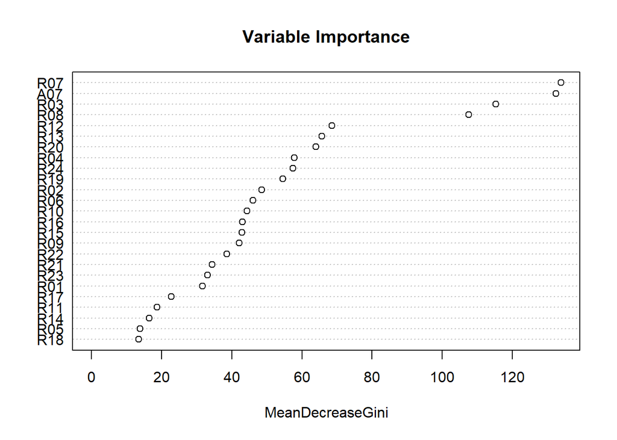

Now we will examine how well the model performed:

```
## Confusion Matrix and Statistics
##
##           Reference
## Prediction  no yes
##        no  435  43
##        yes  37 397
##
##                Accuracy : 0.9123
##                  95% CI : (0.892, 0.9298)
##     No Information Rate : 0.5175
##     P-Value [Acc > NIR] : <2e-16
##
##                   Kappa : 0.8243
##
##  Mcnemar's Test P-Value : 0.5762
##
##             Sensitivity : 0.9216
##             Specificity : 0.9023
##          Pos Pred Value : 0.9100
##          Neg Pred Value : 0.9147
##              Prevalence : 0.5175
##          Detection Rate : 0.4770
##    Detection Prevalence : 0.5241
##       Balanced Accuracy : 0.9119
##
##        'Positive' Class : no
##
```

Note that we used not voting (denoted by the outcome “no”) as the positive outcome, as we are trying to find out who will not vote.

We found that we were able to correctly predict the voting outcome of 91.23% of voters. The sensitivity of the model is 92.16%, meaning that it was able to correctly predict the outcome “no” for 92.16% of the voters that did not vote. The specificity of the model is 90.23%, meaning it was able to correctly predict the outcome “yes” for 90.23% of the voters that did vote.

## Discussion

### 1. Findings

We will first answer problem 1 on the effects of media consumption on voter outcomes. Based on the Logistic Regression model, we found different media strategies contributed to a higher voting outcome. Below are the results of the logistic regression model:

```
## (Intercept)         C08         C09         C10         C11
##   0.1504207   1.4061205   1.0392692   1.1308846   1.3503806
```

Second, we will address the results from the Random Forest model in addressing the second problem.As mentioned in the results section, the following shows the demographic variables that contribute the most to voting outcome.

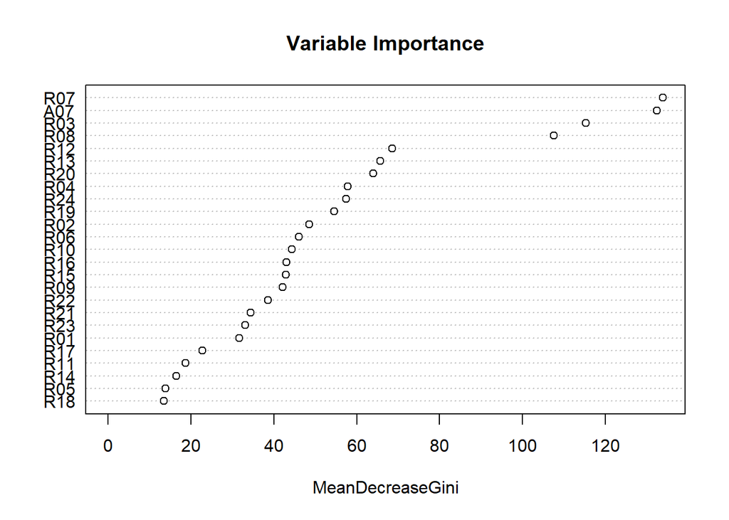

In this model, the 4 most important variables are, in order of importance, level of education, party identification, age, and family income.

Based on the accuracy, sensitivity and specificity of the model as shown in the results section, we can conclude that we have solved problem 2 as we have created a sufficiently accurate model. Further, we have also narrowed the most relevant demographic variables that influence voting outcome.

### 2. Implications and Further Research

The implications of our solution to problem 2 is that political campaigners should focus on appealing to those of different levels education, all party identification, all age populations, and those from all income brackets. Another interpretation is that individuals with certain levels of such traits have less opportunity to vote, and the government should work on avenues that would enable more people from such demographics to vote. However, the exact correlation (positive or negative) between these predictors and the outcome are yet to be determined. Further research should be done into these correlations.

Our suggestions for those looking to answer the same problems we are would be to work with a dataset with a lower number of missing values, as we had to impute the missing values, thus leaving room for error. Increasing the size of the dataset would be beneficial as well, as it would be more representative of the US population. This would also balance the distribution of outcome variables. Another improvement for balancing the distribution of outcome variables, cross-validation prior to oversampling may reduce overfitting. Considering our high accuracy, this might be an issue. Another option for balancing the output variables is SMOTE.